# Heart Failure Inferential Modeling

Lin Htet Naing

2026-01-16

## 1 Project Overview

This project investigates factors associated with mortality among patients with heart failure using inferential statistical methods. The analysis is based on the Heart Failure Clinical Records dataset from the UCI Machine Learning Repository, which includes demographic characteristics, clinical conditions, and laboratory findings for patients diagnosed with heart failure. The dataset contains both a binary mortality indicator (DEATH_EVENT) and a time-to-event variable (time), enabling analysis of mortality status as well as survival over follow-up. Details of the dataset can be found in the UCI repository (https://archive.ics.uci.edu/dataset/519/heart+failure+clinical+records).

The primary objective of this study is to identify demographic and clinical predictors of mortality and to assess how these factors influence both the odds and timing of death. To achieve this, multivariable logistic regression was used to estimate adjusted associations with mortality status, while Cox proportional hazards model was applied to account for follow-up time and censoring. Together, these complementary approaches provide a comprehensive and interpretable assessment of mortality risk in heart failure patients.

```r
# Load the dataset
heart_failure <-
    read_csv("https://raw.githubusercontent.com/linhnslu/heart_failure_clinical_records/refs/heads/main/heart_failure_clinical_records_dataset.csv")
```

## 2 Data Preparation

```r
# check the data
# glimpse(heart_failure)
# Convert categorical variables to factors
df <- heart_failure
df <- df |>
    mutate(
        DEATH_EVENT = factor(DEATH_EVENT,
                             levels = c(0, 1),
                             labels = c("Survived", "Dead")),
        sex = factor(sex,
                     levels = c(0, 1),
                     labels = c("Women", "Men")),
        anaemia = factor(anaemia,
                         levels = c(0, 1),
                         labels = c("Absent", "Present")),
        diabetes = factor(diabetes,
                          levels = c(0, 1),
                          labels = c("Absent", "Present")),
        high_blood_pressure = factor(high_blood_pressure,
                                     levels = c(0, 1),
                                     labels = c("Absent", "Present")),
        smoking = factor(smoking,
                         levels = c(0, 1),
                         labels = c("Absent", "Present"))
  )
summary(df)
```

```
##       age           anaemia    creatinine_phosphokinase    diabetes
##  Min.   :40.00   Absent :170   Min.   :  23.0           Absent :174
##  1st Qu.:51.00   Present:129   1st Qu.: 116.5           Present:125
##  Median :60.00                 Median : 250.0
##  Mean   :60.83                 Mean   : 581.8
##  3rd Qu.:70.00                 3rd Qu.: 582.0
##  Max.   :95.00                 Max.   :7861.0
##  ejection_fraction high_blood_pressure   platelets      serum_creatinine
##  Min.   :14.00     Absent :194         Min.   : 25100   Min.   :0.500
##  1st Qu.:30.00     Present:105         1st Qu.:212500   1st Qu.:0.900
##  Median :38.00                         Median :262000   Median :1.100
##  Mean   :38.08                         Mean   :263358   Mean   :1.394
##  3rd Qu.:45.00                         3rd Qu.:303500   3rd Qu.:1.400
##  Max.   :80.00                         Max.   :850000   Max.   :9.400
##   serum_sodium      sex         smoking         time         DEATH_EVENT
##  Min.   :113.0   Women:105   Absent :203   Min.   :  4.0   Survived:203
##  1st Qu.:134.0   Men  :194   Present: 96   1st Qu.: 73.0   Dead    : 96
##  Median :137.0                             Median :115.0
##  Mean   :136.6                             Mean   :130.3
##  3rd Qu.:140.0                             3rd Qu.:203.0
##  Max.   :148.0                             Max.   :285.0
```

```r
# check missing values
colSums(is.na(df)) # No missing values detected
```

```
##                      age                  anaemia creatinine_phosphokinase
##                        0                        0                        0
##                 diabetes        ejection_fraction      high_blood_pressure
##                        0                        0                        0
##                platelets         serum_creatinine             serum_sodium
##                        0                        0                        0
##                      sex                  smoking                     time
##                        0                        0                        0
##              DEATH_EVENT
##                        0
```

There is no missing data in the dataset.

## 3 Data Distribution, Summary Statistics, and Statistical Tests

### 3.1 Categorical Variables

```r
# summary statistics and chi-squared test for categorical variables
# event vs anaemia
event_anaemia <- df |>
    select("anaemia" = anaemia, "mortality" = DEATH_EVENT) |>
    table()
event_anaemia
```

```
##          mortality
## anaemia   Survived Dead
##   Absent       120   50
##   Present       83   46
```

```r
round(prop.table(event_anaemia, 1), 2) # Row proportions
```

```
##          mortality
## anaemia   Survived Dead
##   Absent      0.71 0.29
##   Present     0.64 0.36
```

```r
chisq.test(event_anaemia)
```

```
##
##  Pearson's Chi-squared test with Yates' continuity correction
##
## data:  event_anaemia
## X-squared = 1.0422, df = 1, p-value = 0.3073
```

```r
# event vs diabetes
event_diabetes <- df |>
    select("diabetes" = diabetes, "mortality" = DEATH_EVENT) |>
    table()
event_diabetes
```

```
##          mortality
## diabetes  Survived Dead
##   Absent       118   56
##   Present       85   40
```

```r
round(prop.table(event_diabetes, 1), 2) # Row proportions
```

```
##          mortality
## diabetes  Survived Dead
##   Absent      0.68 0.32
##   Present     0.68 0.32
```

```r
chisq.test(event_diabetes)
```

```
##
##  Pearson's Chi-squared test with Yates' continuity correction
##
## data:  event_diabetes
## X-squared = 2.1617e-30, df = 1, p-value = 1
```

```r
# event vs high blood pressure
event_hbp <- df |>
    select("high_blood_pressure" = high_blood_pressure, "mortality" = DEATH_EVENT) |>
    table()
event_hbp
```

```
##                    mortality
## high_blood_pressure Survived Dead
##             Absent       137   57
##             Present       66   39
```

```r
round(prop.table(event_hbp, 1), 2) # Row proportions
```

```
##                    mortality
## high_blood_pressure Survived Dead
##             Absent      0.71 0.29
##             Present     0.63 0.37
```

```r
chisq.test(event_hbp)
```

```
##
##  Pearson's Chi-squared test with Yates' continuity correction
##
## data:  event_hbp
## X-squared = 1.5435, df = 1, p-value = 0.2141
```

```r
# event vs smoking
event_smoking <- df |>
    select("smoking" = smoking, "mortality" = DEATH_EVENT) |>
    table()
event_smoking
```

```
##          mortality
## smoking   Survived Dead
##   Absent       137   66
##   Present       66   30
```

```r
round(prop.table(event_smoking, 1), 2) # Row proportions
```

```
##          mortality
## smoking   Survived Dead
##   Absent      0.67 0.33
##   Present     0.69 0.31
```

```r
chisq.test(event_smoking)
```

```
##
##  Pearson's Chi-squared test with Yates' continuity correction
##
## data:  event_smoking
## X-squared = 0.0073315, df = 1, p-value = 0.9318
```

```r
# event vs sex
event_sex <- df |>
    select("sex" = sex, "mortality" = DEATH_EVENT) |>
    table()
event_sex # 0 = woman, 1 = man
```

```
##        mortality
## sex     Survived Dead
##   Women       71   34
##   Men        132   62
```

```r
round(prop.table(event_sex, 1), 2) # Row proportions
```

```
##        mortality
## sex     Survived Dead
##   Women     0.68 0.32
##   Men       0.68 0.32
```

```r
chisq.test(event_sex)
```

```
##
##  Pearson's Chi-squared test with Yates' continuity correction
##
## data:  event_sex
## X-squared = 0, df = 1, p-value = 1
```

There were no statistically significant differences in categorical variables between the outcome groups (all $p > 0.05$). Specifically, the distribution of gender and the prevalence of anaemia, diabetes, hypertension, and smoking status were comparable between patients who experienced the event and those who did not.

### 3.2 Numerical Variables

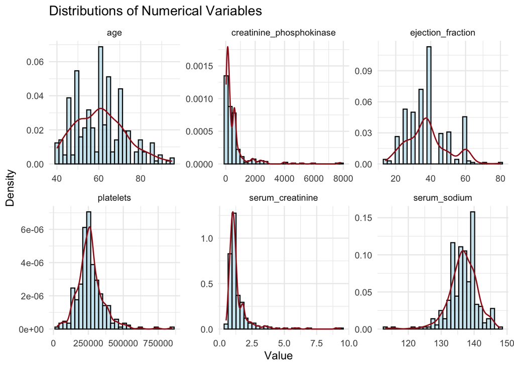

```r
# Check data distribution
# Numerical variables
num_vars <- c("age", "creatinine_phosphokinase", "ejection_fraction",
              "platelets","serum_creatinine", "serum_sodium")
df_num <- df |>
    select(all_of(num_vars)) |>
    pivot_longer(cols = everything(), names_to = "variable", values_to = "value")

ggplot(df_num, aes(x = value)) +
    geom_histogram(aes(y = after_stat(density)), bins = 30, fill = "lightblue", color = "black", alpha = 0.6) +
    geom_density(color = "#9E1C21", linewidth = 0.6, adjust = 1) +
    facet_wrap(~ variable, scales = "free") +
    theme_minimal() +
    labs(title = "Distributions of Numerical Variables", x = "Value", y = "Density")
```

```r
# Checking normality with Shapiro-Wilk test
shapiro_results <- df_num |>
    group_by(variable) |>
    summarise(
        shapiro_p_value = shapiro.test(value)$p.value
    )
print(shapiro_results) # All p-values < 0.05, indicating non-normal distributions
```

```
## # A tibble: 6 × 2
##   variable                 shapiro_p_value
##   <chr>                              <dbl>
## 1 age                             5.35e- 5
## 2 creatinine_phosphokinase        7.05e-28
## 3 ejection_fraction               7.22e- 9
## 4 platelets                       2.88e-12
## 5 serum_creatinine                5.39e-27
## 6 serum_sodium                    9.21e-10
```

Distribution plots and Shapiro-Wilk test results indicate that the numerical variables are not normally distributed. Therefore, median and interquartile range (IQR) will be used as summary statistics, and non-parametric tests will be employed for inferential analysis.

```r
# summary statistics stratified by DEATH_EVENT
# summary statistics for numerical variables
num_summary <- df |>
    select(DEATH_EVENT, all_of(num_vars)) |>
    pivot_longer(cols = -DEATH_EVENT, names_to = "variable", values_to = "value") |>
    group_by(DEATH_EVENT, variable) |>
    summarise(
        mean = mean(value),
        sd = sd(value),
        median = median(value),
        IQR = IQR(value)
    )
print(num_summary)
```

```
## # A tibble: 12 × 6
## # Groups:   DEATH_EVENT [2]
##    DEATH_EVENT variable                      mean        sd   median        IQR
##    <fct>       <chr>                        <dbl>     <dbl>    <dbl>      <dbl>
##  1 Survived    age                          58.8     10.6       60       15
##  2 Survived    creatinine_phosphokinase    540.     754.       245      473
##  3 Survived    ejection_fraction            40.3     10.9       38       10
##  4 Survived    platelets                266657.   97531.    263000    82500
##  5 Survived    serum_creatinine              1.18     0.654      1        0.3
##  6 Survived    serum_sodium                137.       3.98     137        4.5
##  7 Dead        age                          65.2     13.2       65       20
##  8 Dead        creatinine_phosphokinase    670.    1317.       259      453.
##  9 Dead        ejection_fraction            33.5     12.5       30       13
## 10 Dead        platelets                256381.   98526.    258500   113500
## 11 Dead        serum_creatinine              1.84     1.47       1.3      0.825
## 12 Dead        serum_sodium                135.       5.00     136.       5.25
```

```r
# Satistical tests for numerical variables: Wilcoxon rank-sum test
num_tests <- df |>
    select(DEATH_EVENT, all_of(num_vars)) |>
    pivot_longer(cols = -DEATH_EVENT, names_to = "variable", values_to = "value") |>
    group_by(variable) |>
    summarise(
        wilcox_statistic = wilcox.test(value ~ DEATH_EVENT)$statistic,
        wilcox_p_value = wilcox.test(value ~ DEATH_EVENT)$p.value
    )
print(num_tests)
```

```
## # A tibble: 6 × 3
##   variable                 wilcox_statistic wilcox_p_value
##   <chr>                               <dbl>          <dbl>
## 1 age                                 7121        1.67e- 4
## 2 creatinine_phosphokinase            9460        6.84e- 1
## 3 ejection_fraction                  13176.       7.37e- 7
## 4 platelets                          10300.       4.26e- 1
## 5 serum_creatinine                    5298        1.58e-10
## 6 serum_sodium                       12262.       2.93e- 4
```

The difference in numerical variables between the two outcome groups is statistically significant for age, ejection fraction, serum creatinine, and serum sodium. The patients with the event had higher median age and serum creatinine levels, but lower median ejection fraction and serum sodium levels.

## 4 Characteristics of Study Participants by the Outcome

```r
# Characteristic table
df |>
    dplyr::select(
        -time,
        "Age (years)" = age,
        "Anaemia" = anaemia,
        "Diabetes" = diabetes,
        "High Blood Pressure" = high_blood_pressure,
        "Smoking" = smoking,
        "Sex" = sex,
        "Ejection Fraction (%)" = ejection_fraction,
        "Platelets (kiloplatelets/mL)" = platelets,
        "Serum Creatinine (mg/dL)" = serum_creatinine,
        "Serum Sodium (mEq/L)" = serum_sodium,
        "Creatinine Phosphokinase (mcg/L)" = creatinine_phosphokinase
    ) |>
    tbl_summary(
        by = DEATH_EVENT,
        statistic = list(
        all_continuous() ~ "{median} ({IQR})",
        all_categorical() ~ "{n} ({p}%)"
        ),
        digits = all_continuous() ~ 1
    ) |>
    add_p(
        test = list(
        all_continuous() ~ "wilcox.test",
        all_categorical() ~ "chisq.test"
        )
    ) |>
    modify_header(label ~ "Characteristic") |>
    bold_labels() |>
    modify_caption(
        "Characteristics of study participants by mortality status"
        )
```

Characteristics of study participants by mortality status

| Characteristic | **Survived** N = 203<sup>1</sup> | **Dead** N = 96<sup>1</sup> | **p-value**<sup>2</sup> |
| --- | --- | --- | --- |
| Age (years) | 60.0 (15.0) | 65.0 (20.0) | <0.001 |
| Anaemia |  |  | 0.3 |
| Absent | 120 (59%) | 50 (52%) |  |
| Present | 83 (41%) | 46 (48%) |  |
| Creatinine Phosphokinase (mcg/L) | 245.0 (473.0) | 259.0 (453.3) | 0.7 |
| Diabetes |  |  | >0.9 |
| Absent | 118 (58%) | 56 (58%) |  |
| Present | 85 (42%) | 40 (42%) |  |
| Ejection Fraction (%) | 38.0 (10.0) | 30.0 (13.0) | <0.001 |
| High Blood Pressure |  |  | 0.2 |
| Absent | 137 (67%) | 57 (59%) |  |
| Present | 66 (33%) | 39 (41%) |  |
| Platelets (kiloplatelets/mL) | 263,000.0 (82,500.0) | 258,500.0 (113,500.0) | 0.4 |
| Serum Creatinine (mg/dL) | 1.0 (0.3) | 1.3 (0.8) | <0.001 |
| Serum Sodium (mEq/L) | 137.0 (4.5) | 135.5 (5.3) | <0.001 |
| Sex |  |  | >0.9 |
| Women | 71 (35%) | 34 (35%) |  |
| Men | 132 (65%) | 62 (65%) |  |
| Smoking |  |  | >0.9 |
| Absent | 137 (67%) | 66 (69%) |  |
| Present | 66 (33%) | 30 (31%) |  |

<sup>1</sup> Median (IQR); n (%)  
<sup>2</sup> Wilcoxon rank sum test; Pearson’s Chi-squared test

## 5 Visualizations

### 5.1 Boxplots for Numerical Variables

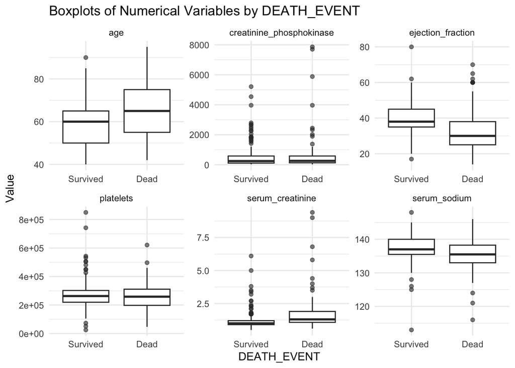

```r
# Visualizations
# Boxplots for numerical variables
df_box <- df |>
  dplyr::select(DEATH_EVENT, all_of(num_vars)) |>
  pivot_longer(cols = -DEATH_EVENT, names_to = "variable", values_to = "value")

ggplot(df_box, aes(x = DEATH_EVENT, y = value)) +
  geom_boxplot(outlier.alpha = 0.6) +
  facet_wrap(~ variable, scales = "free") +
  theme_minimal() +
  labs(title = "Boxplots of Numerical Variables by DEATH_EVENT",
       x = "DEATH_EVENT",
       y = "Value") +
  theme(legend.position = "none")
```

### 5.2 Correlation Matrix

```r
# Check correlations among numerical variables
num_data <- df |> dplyr::select(all_of(num_vars))
cor_matrix <- cor(num_data)
print(cor_matrix)
```

```
##                                  age creatinine_phosphokinase ejection_fraction
## age                       1.00000000              -0.08158390        0.06009836
## creatinine_phosphokinase -0.08158390               1.00000000       -0.04407955
## ejection_fraction         0.06009836              -0.04407955        1.00000000
## platelets                -0.05235437               0.02446339        0.07217747
## serum_creatinine          0.15918713              -0.01640848       -0.01130247
## serum_sodium             -0.04596584               0.05955016        0.17590228
##                            platelets serum_creatinine serum_sodium
## age                      -0.05235437       0.15918713  -0.04596584
## creatinine_phosphokinase  0.02446339      -0.01640848   0.05955016
## ejection_fraction         0.07217747      -0.01130247   0.17590228
## platelets                 1.00000000      -0.04119808   0.06212462
## serum_creatinine         -0.04119808       1.00000000  -0.18909521
## serum_sodium              0.06212462      -0.18909521   1.00000000
```

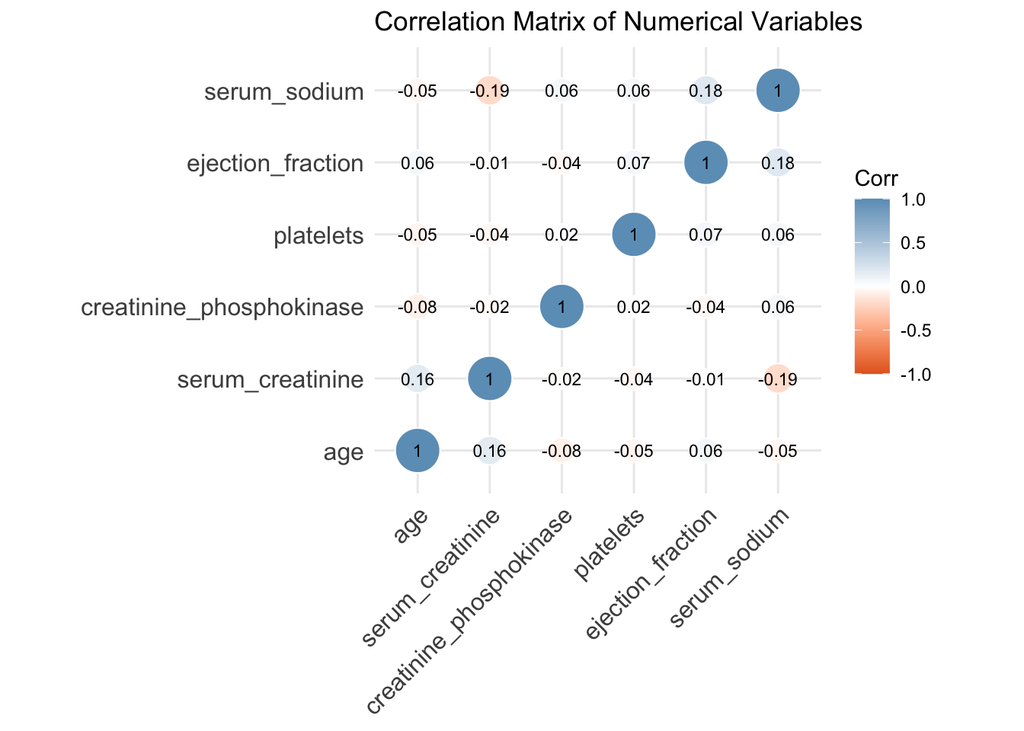

```r
# Visualize correlation matrix
ggcorrplot::ggcorrplot(cor_matrix,
                method = "circle",
                lab = TRUE,
                lab_size = 3,                # label size
                hc.order = TRUE,             # Clusters similar variables together
                colors = c("#E46726", "white", "#6D9EC1"), # color palette
                outline.color = "white",     # Cleaner look
                title = "Correlation Matrix of Numerical Variables",
                ggtheme = theme_minimal())
```

Numerical variables exhibited weak correlations. No evidence of substantial multicollinearity detected.

## 6 Multivariable Logistic Regression

Multivariable logistic regression models will be developed to assess the association between features and the outcome variable (DEATH_EVENT). A model with full feature set will be developed first and then reduced using backward elimination based on AIC.

```r
# Full model
full_model <- glm(DEATH_EVENT ~ age + creatinine_phosphokinase + ejection_fraction +
                        platelets + serum_creatinine + serum_sodium + anaemia +
                        diabetes + high_blood_pressure + sex + smoking, #time is irrelevant in logistic regression and excluded to avoid data leakage
                    data = df,
                    family = binomial)
summary(full_model)
```

```
##
## Call:
## glm(formula = DEATH_EVENT ~ age + creatinine_phosphokinase +
##     ejection_fraction + platelets + serum_creatinine + serum_sodium +
##     anaemia + diabetes + high_blood_pressure + sex + smoking,
##     family = binomial, data = df)
##
## Coefficients:
##                              Estimate Std. Error z value Pr(>|z|)
## (Intercept)                 4.964e+00  4.601e+00   1.079 0.280625
## age                         5.569e-02  1.313e-02   4.241 2.23e-05 ***
## creatinine_phosphokinase    2.905e-04  1.428e-04   2.034 0.041907 *
## ejection_fraction          -7.032e-02  1.486e-02  -4.731 2.23e-06 ***
## platelets                  -7.094e-07  1.617e-06  -0.439 0.660857
## serum_creatinine            6.619e-01  1.734e-01   3.817 0.000135 ***
## serum_sodium               -5.667e-02  3.338e-02  -1.698 0.089558 .
## anaemiaPresent              4.179e-01  3.009e-01   1.389 0.164904
## diabetesPresent             1.514e-01  2.974e-01   0.509 0.610644
## high_blood_pressurePresent  4.189e-01  3.061e-01   1.369 0.171092
## sexMen                     -3.990e-01  3.508e-01  -1.137 0.255394
## smokingPresent              1.356e-01  3.486e-01   0.389 0.697300
## ---
## Signif. codes:  0 '***' 0.001 '**' 0.01 '*' 0.05 '.' 0.1 ' ' 1
##
## (Dispersion parameter for binomial family taken to be 1)
##
##     Null deviance: 375.35  on 298  degrees of freedom
## Residual deviance: 294.28  on 287  degrees of freedom
## AIC: 318.28
##
## Number of Fisher Scoring iterations: 5
```

The full model has AIC value 318.28 and identified age, ejection fraction, serum creatinine, and creatinine_phosphokinase as significant predictors of DEATH_EVENT (p < 0.05).

A parsimonious model with a better AIC will be sought through stepwise selection with backward elimination.

```r
# Stepwise model selection using AIC - Backward elimination
step_model <- step(full_model, direction = "backward" , trace = 1)
```

```
## Start:  AIC=318.28
## DEATH_EVENT ~ age + creatinine_phosphokinase + ejection_fraction +
##     platelets + serum_creatinine + serum_sodium + anaemia + diabetes +
##     high_blood_pressure + sex + smoking
##
##                            Df Deviance    AIC
## - smoking                   1   294.43 316.43
## - platelets                 1   294.47 316.47
## - diabetes                  1   294.54 316.54
## - sex                       1   295.58 317.58
## - high_blood_pressure       1   296.15 318.15
## - anaemia                   1   296.22 318.22
## <none>                          294.28 318.28
## - serum_sodium              1   297.21 319.21
## - creatinine_phosphokinase  1   298.46 320.46
## - serum_creatinine          1   314.04 336.04
## - age                       1   314.06 336.06
## - ejection_fraction         1   320.96 342.96
##
## Step:  AIC=316.43
## DEATH_EVENT ~ age + creatinine_phosphokinase + ejection_fraction +
##     platelets + serum_creatinine + serum_sodium + anaemia + diabetes +
##     high_blood_pressure + sex
##
##                            Df Deviance    AIC
## - platelets                 1   294.61 314.61
## - diabetes                  1   294.68 314.68
## - sex                       1   295.59 315.59
## - anaemia                   1   296.28 316.28
## - high_blood_pressure       1   296.29 316.29
## <none>                          294.43 316.43
## - serum_sodium              1   297.35 317.35
## - creatinine_phosphokinase  1   298.51 318.51
## - serum_creatinine          1   314.07 334.07
## - age                       1   314.17 334.17
## - ejection_fraction         1   321.18 341.18
##
## Step:  AIC=314.61
## DEATH_EVENT ~ age + creatinine_phosphokinase + ejection_fraction +
##     serum_creatinine + serum_sodium + anaemia + diabetes + high_blood_pressure +
```

[output cut: 28 more lines]

```
## - ejection_fraction         1   321.68 337.68
##
## Step:  AIC=312.05
## DEATH_EVENT ~ age + creatinine_phosphokinase + ejection_fraction +
##     serum_creatinine + serum_sodium + anaemia + high_blood_pressure
##
##                            Df Deviance    AIC
## <none>                          296.05 312.05
## - anaemia                   1   298.16 312.16
## - high_blood_pressure       1   298.42 312.42
## - serum_sodium              1   299.06 313.06
## - creatinine_phosphokinase  1   299.72 313.72
## - age                       1   314.73 328.73
## - serum_creatinine          1   315.76 329.76
## - ejection_fraction         1   321.83 335.83
```

```r
summary(step_model)
```

```
##
## Call:
## glm(formula = DEATH_EVENT ~ age + creatinine_phosphokinase +
##     ejection_fraction + serum_creatinine + serum_sodium + anaemia +
##     high_blood_pressure, family = binomial, data = df)
##
## Coefficients:
##                              Estimate Std. Error z value Pr(>|z|)
## (Intercept)                 4.7298351  4.5190849   1.047  0.29527
## age                         0.0530244  0.0127859   4.147 3.37e-05 ***
## creatinine_phosphokinase    0.0002674  0.0001405   1.902  0.05713 .
## ejection_fraction          -0.0679014  0.0145626  -4.663 3.12e-06 ***
## serum_creatinine            0.6619016  0.1711437   3.868  0.00011 ***
## serum_sodium               -0.0568437  0.0330681  -1.719  0.08562 .
## anaemiaPresent              0.4309325  0.2980595   1.446  0.14824
## high_blood_pressurePresent  0.4606311  0.2992103   1.539  0.12368
## ---
## Signif. codes:  0 '***' 0.001 '**' 0.01 '*' 0.05 '.' 0.1 ' ' 1
##
## (Dispersion parameter for binomial family taken to be 1)
##
##     Null deviance: 375.35  on 298  degrees of freedom
## Residual deviance: 296.05  on 291  degrees of freedom
## AIC: 312.05
##
## Number of Fisher Scoring iterations: 5
```

### 6.1 Logistic Regression Model: Assumptions and Diagnostics

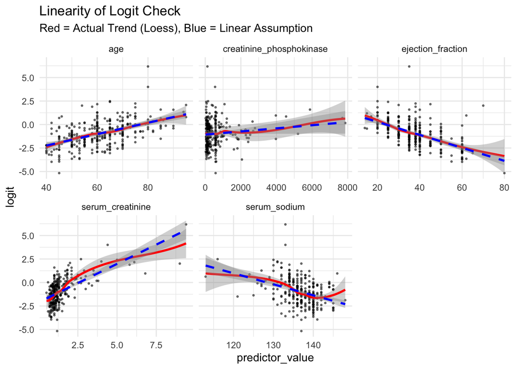

```r
# Model Diagnostics: 1. logit linearity for stepwise model (log-odds vs predictors)
# predicted probabilities
probabilities <- predict(step_model, type = "response")

# select continuous variables included in the model and bind with logit

df_step_visual <- df |>
  mutate(logit = log(probabilities / (1 - probabilities))) |> # log-odds
  select(logit, age, creatinine_phosphokinase, ejection_fraction, serum_creatinine, serum_sodium,) |>
  gather(key = "predictors", value = "predictor_value", -logit)

# log-odds vs predictors plot
ggplot(df_step_visual, aes(predictor_value, logit)) +
  geom_point(size = 0.5, alpha = 0.5) +
  geom_smooth(method = "loess", color = "red") +
  geom_smooth(method = "lm", color = "blue", linetype = "dashed") +
  facet_wrap(~predictors, scales = "free_x") +
  theme_minimal() +
  labs(title = "Linearity of Logit Check",
       subtitle = "Red = Actual Trend (Loess), Blue = Linear Assumption")
```

The predictors age, creatinine phosphoskinase, and ejection fraction closely follow the linear assumption line and thus appear to meet the linearity assumption. Serum creatinine and serum sodium show slight deviation, but not severe enough to warrant concern. (Note: models with transformed variables such as log transformations were tested but did not significantly improve model fit nor the logit linearity assumption.)

```r
# Model Diagnostics: 2. Multicollinearity check using Variance Inflation Factor (VIF)
car::vif(step_model)
```

```
##                      age creatinine_phosphokinase        ejection_fraction
##                 1.085777                 1.088111                 1.096840
##         serum_creatinine             serum_sodium                  anaemia
##                 1.050969                 1.057987                 1.076613
##      high_blood_pressure
##                 1.022362
```

VIF values for all predictors were below 5, indicating no significant multicollinearity issues in the logistic regression model.

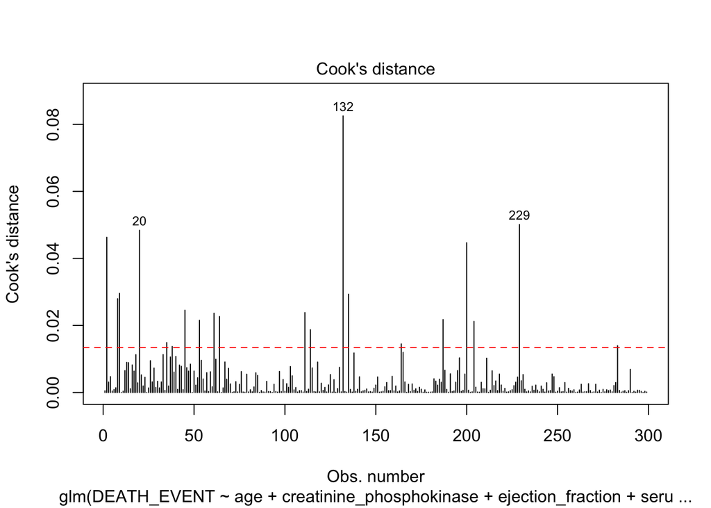

```r
# Model Diagnostics: 3. Influential observations check using Cook's distance
plot(step_model, which = 4, id.n = 3)

# Generally, points with Cook's distance > 4/n are considered influential
abline(h = 4/nrow(df), col = "red", lty = 2)
```

```r
# Checking observations with high Cook's distance
cooksd <- cooks.distance(step_model)
influential_points <- which(cooksd > (4/nrow(df)))
View(df[influential_points, ])
```

```r
# Model Diagnostics: 4. Overall model fit check using Hosmer-Lemeshow test
generalhoslem::logitgof(df$DEATH_EVENT, fitted(step_model))
```

```
##
##  Hosmer and Lemeshow test (binary model)
##
## data:  df$DEATH_EVENT, fitted(step_model)
## X-squared = 13.134, df = 8, p-value = 0.1073
```

The Hosmer–Lemeshow test suggested that the stepwise logistic regression model fit the data adequately, as the p-value was greater than 0.05. Diagnostic checks revealed several influential points (high Cook’s distance). These observations featured high, yet plausible, creatinine and CPK values. Since no data entry errors were found and given the relatively small sample size, these points were retained in the analysis.

Because the stepwise model demonstrated good fit and the influential points were not erroneous, it will be considered as the final model. The model is robust for inferential purposes.

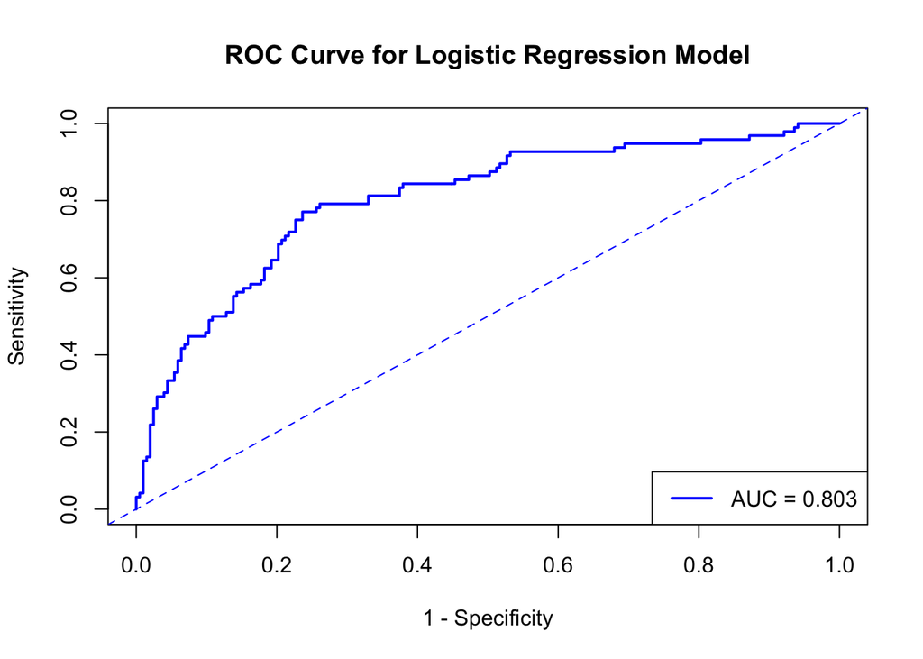

```r
final_model <- step_model
# Model Performance: Discriminative ability using ROC curve and AUC for the final model
# ROC object
roc_obj <- roc(df$DEATH_EVENT, fitted(final_model))
auc_value <- auc(roc_obj)
plot(x = 1 - roc_obj$specificities, y = roc_obj$sensitivities, type = "l",
     xlab = "1 - Specificity", ylab = "Sensitivity",
     main = "ROC Curve for Logistic Regression Model", col = "blue", lwd = 2)
abline(0, 1, lty = 2, col = "blue")
legend("bottomright", legend = paste("AUC =", round(auc_value, 3)), col = "blue", lwd = 2)
```

The final model demonstrated good discriminative ability, as indicated by the ROC curve and AUC value (0.803).

### 6.2 Logistic Regression Model: Interpretation

```r
# Interpretations
summary(final_model)
```

```
##
## Call:
## glm(formula = DEATH_EVENT ~ age + creatinine_phosphokinase +
##     ejection_fraction + serum_creatinine + serum_sodium + anaemia +
##     high_blood_pressure, family = binomial, data = df)
##
## Coefficients:
##                              Estimate Std. Error z value Pr(>|z|)
## (Intercept)                 4.7298351  4.5190849   1.047  0.29527
## age                         0.0530244  0.0127859   4.147 3.37e-05 ***
## creatinine_phosphokinase    0.0002674  0.0001405   1.902  0.05713 .
## ejection_fraction          -0.0679014  0.0145626  -4.663 3.12e-06 ***
## serum_creatinine            0.6619016  0.1711437   3.868  0.00011 ***
## serum_sodium               -0.0568437  0.0330681  -1.719  0.08562 .
## anaemiaPresent              0.4309325  0.2980595   1.446  0.14824
## high_blood_pressurePresent  0.4606311  0.2992103   1.539  0.12368
## ---
## Signif. codes:  0 '***' 0.001 '**' 0.01 '*' 0.05 '.' 0.1 ' ' 1
##
## (Dispersion parameter for binomial family taken to be 1)
##
##     Null deviance: 375.35  on 298  degrees of freedom
## Residual deviance: 296.05  on 291  degrees of freedom
## AIC: 312.05
##
## Number of Fisher Scoring iterations: 5
```

```r
# publication-ready table
final_model |>
    tbl_regression(
        exponentiate = TRUE,
        show_single_row = c(anaemia, high_blood_pressure),
        label = list(
        age ~ "Age (years)",
        creatinine_phosphokinase ~ "Creatinine phosphokinase (mcg/L)",
        ejection_fraction ~ "Ejection fraction (%)",
        serum_creatinine ~ "Serum creatinine (mg/dL)",
        serum_sodium ~ "Serum sodium (mEq/L)",
        anaemia ~ "Anaemia (Present vs Absent)",
        high_blood_pressure ~ "High blood pressure (Present vs Absent)"
        )
    ) |>
    bold_labels() |>
    bold_p(t = 0.05) |>
    modify_caption(
        "Multivariable logistic regression examining factors associated with mortality among heart failure patients"
        )
```

Multivariable logistic regression examining factors associated with mortality among heart failure patients

| **Characteristic** | **OR** | **95% CI** | **p-value** |
| --- | --- | --- | --- |
| Age (years) | 1.05 | 1.03, 1.08 | <0.001 |
| Creatinine phosphokinase (mcg/L) | 1.00 | 1.00, 1.00 | 0.057 |
| Ejection fraction (%) | 0.93 | 0.91, 0.96 | <0.001 |
| Serum creatinine (mg/dL) | 1.94 | 1.43, 2.83 | <0.001 |
| Serum sodium (mEq/L) | 0.94 | 0.88, 1.01 | 0.086 |
| Anaemia (Present vs Absent) | 1.54 | 0.86, 2.77 | 0.15 |
| High blood pressure (Present vs Absent) | 1.59 | 0.88, 2.86 | 0.12 |

Abbreviations: CI = Confidence Interval, OR = Odds Ratio

Multivariable logistic regression model revealed that age, ejection fraction, and serum creatinine were associated with mortality. After adjusting other variables included in the model, each additional year of age increased the odds of death by 5% (OR = 1.05, 95% CI 1.03–1.08). Similarly, each 1 mg/dL increase in serum creatinine nearly doubled mortality odds (OR = 1.94, 95% CI 1.43–2.83). In contrast, higher ejection fraction was protective and reduced the odds of death by approximately 7% (OR = 0.93, 95% CI 0.91–0.96). Creatinine phosphokinase and serum sodium showed borderline associations, and anaemia and high blood pressure were not significantly associated with mortality after adjustment.

Although multivariable logistic regression was used to estimate associations between patient characteristics and mortality, this approach does not account for differences in follow-up duration or the timing of death. Given that time-to-event data were available, a Cox proportional hazards model was additionally fitted to evaluate the association between covariates and the hazard of death while appropriately accounting for censoring.

## 7 Cox Proportional Hazards Model

Predictor selection for the Cox model was guided by clinical relevance and prior evidence, with logistic regression results used to support, but not solely determine, variable inclusion.

```r
df <- df |>
    mutate(DEATH_EVENT = ifelse(DEATH_EVENT == 'Dead', 1, 0))
# Create a survival object
surv_obj <- Surv(time = df$time, event = df$DEATH_EVENT)

# Fit Cox proportional hazards model
cox_model <- coxph(surv_obj ~ age + ejection_fraction +
                        serum_creatinine + serum_sodium + anaemia + diabetes + high_blood_pressure, data = df)
summary(cox_model)
```

```
## Call:
## coxph(formula = surv_obj ~ age + ejection_fraction + serum_creatinine +
##     serum_sodium + anaemia + diabetes + high_blood_pressure,
##     data = df)
##
##   n= 299, number of events= 96
##
##                                 coef exp(coef)  se(coef)      z Pr(>|z|)
## age                         0.045089  1.046121  0.009229  4.885 1.03e-06 ***
## ejection_fraction          -0.046858  0.954223  0.010207 -4.591 4.42e-06 ***
## serum_creatinine            0.313765  1.368568  0.071388  4.395 1.11e-05 ***
## serum_sodium               -0.041276  0.959564  0.023812 -1.733   0.0830 .
## anaemiaPresent              0.372246  1.450990  0.210073  1.772   0.0764 .
## diabetesPresent             0.131061  1.140037  0.220203  0.595   0.5517
## high_blood_pressurePresent  0.467812  1.596497  0.212662  2.200   0.0278 *
## ---
## Signif. codes:  0 '***' 0.001 '**' 0.01 '*' 0.05 '.' 0.1 ' ' 1
##
##                            exp(coef) exp(-coef) lower .95 upper .95
## age                           1.0461     0.9559    1.0274    1.0652
## ejection_fraction             0.9542     1.0480    0.9353    0.9735
## serum_creatinine              1.3686     0.7307    1.1899    1.5741
## serum_sodium                  0.9596     1.0421    0.9158    1.0054
## anaemiaPresent                1.4510     0.6892    0.9613    2.1902
## diabetesPresent               1.1400     0.8772    0.7404    1.7553
## high_blood_pressurePresent    1.5965     0.6264    1.0523    2.4221
##
## Concordance= 0.732  (se = 0.028 )
## Likelihood ratio test= 77.32  on 7 df,   p=5e-14
## Wald test            = 84.36  on 7 df,   p=2e-15
## Score (logrank) test = 84.21  on 7 df,   p=2e-15
```

### 7.1 Cox Proportional Hazards Model: Assumptions & Diagnostics

```
##                        chisq df     p
## age                 0.097420  1 0.755
## ejection_fraction   4.459177  1 0.035
## serum_creatinine    1.650951  1 0.199
## serum_sodium        0.104056  1 0.747
## anaemia             0.000461  1 0.983
## diabetes            0.202440  1 0.653
## high_blood_pressure 0.007867  1 0.929
## GLOBAL              8.434461  7 0.296
```

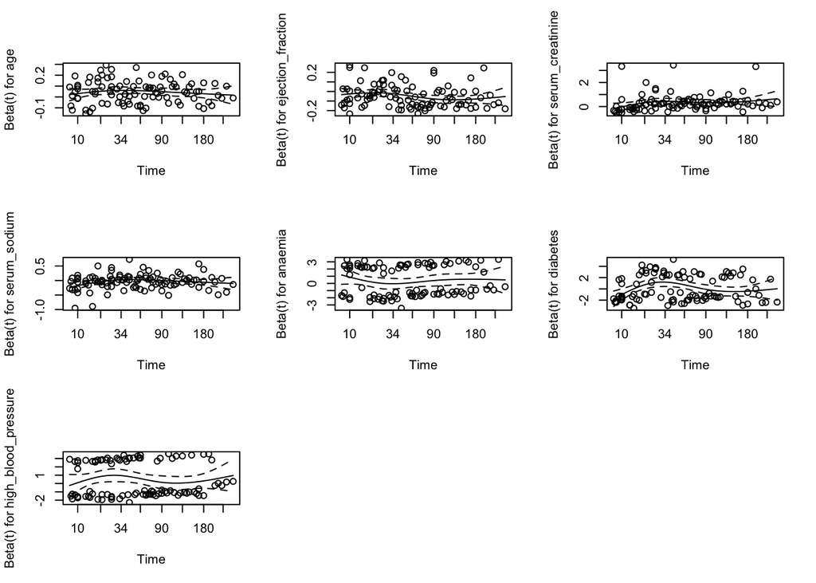

```r
# Model Diagnostics 1: Proportional Hazards Assumption
cox_zph <- cox.zph(cox_model)
par(mfrow = c(3, 3))
plot(cox_zph)
print(cox_zph)
```

The proportional hazards assumption was assessed using Schoenfeld residuals. The ejection fraction covariate showed some indication of deviation from proportionality, but the global test of proportional hazards was not rejected (p = 0.296). In the plot of Schoenfeld residuals for ejection fraction, the pattern was broadly similar to the other covariates, although the residuals showed a mildly time-varying trend. Given that the global test was not significant and the residual pattern for ejection fraction did not differ markedly from the others, the proportional hazards assumption was considered to be reasonably satisfied.

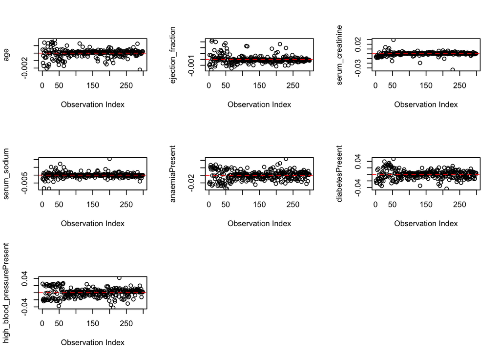

```r
# Model Diagnostics 2: Influential observations check using dfbetas
dfbeta_values <- residuals(cox_model, type = "dfbeta")
par(mfrow = c(3,3))
for(i in 1:ncol(dfbeta_values)) {
    plot(dfbeta_values[, i], main = colnames(dfbeta_values)[i], ylab = names(coef(cox_model))[i], xlab = "Observation Index")
    abline(h=0, col="red", lty=2)
}
```

Comparing the magnitudes of the largest dfbeta values to the regression coeﬃcients suggests that none of the cases are terribly influential individually.

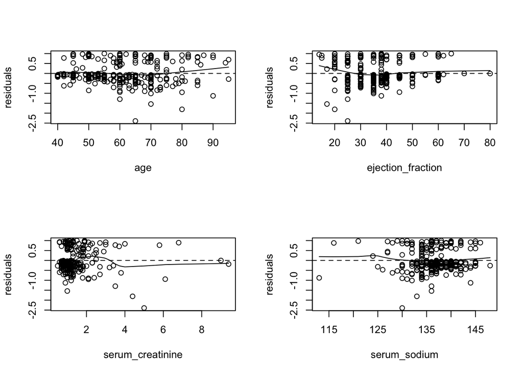

```r
# Model Diagnostics 3: Check for non-linearity using Martingale residuals

martingale_residuals <- residuals(cox_model, type = "martingale")
X <- as.matrix(df[, c("age", "ejection_fraction", "serum_creatinine",
                      "serum_sodium")]) # continuous predictors matrix

# residuals plots
par(mfrow = c(2, 2))
for(j in 1:4){
        plot(X[,j], martingale_residuals,
             xlab = c("age", "ejection_fraction", "serum_creatinine",
             "serum_sodium")[j],
             ylab = "residuals")
        abline(h = 0, lty = 2)
        lines(lowess(X[, j], martingale_residuals, iter = 0))
}
```

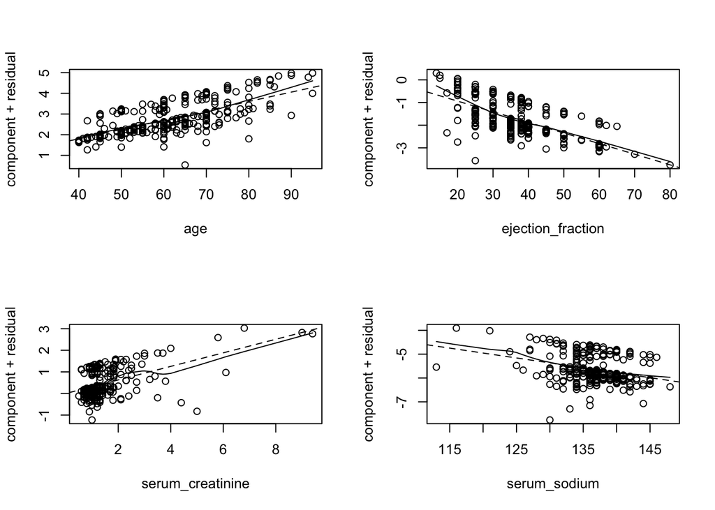

```r
b <- coef(cox_model)[c("age","ejection_fraction", "serum_creatinine", "serum_sodium")] #extract coeffients
#component-plus-residual plots
par(mfrow = c(2, 2))
for(j in 1:4){
        plot(X[, j], b[j]*X[,j] + martingale_residuals,
             xlab = c("age","ejection_fraction", "serum_creatinine", "serum_sodium")[j],
             ylab = "component + residual")
        abline(lm(b[j]*X[, j] + martingale_residuals ~ X[, j]), lty = 2)
        lines(lowess(X[, j], b[j]*X[, j] + martingale_residuals, iter = 0))
}
```

The linearity assumption between the continuous predictors and the log-hazard of the Cox proportional hazards model was evaluated using Martingale and Component plus Residual plots. The Martingale residual plots for age, ejection fraction, serum creatinine, and serum sodium showed a stable, approximately horizontal trend centered at zero, suggesting that the log-hazard for each covariate was adequately modeled as a linear function. The Component plus Residual plots further supported this, as the smoothed trends closely followed the predicted linear reference lines for all variables.

According to model diagnostics, the proportional hazards assumption was reasonably satisfied, and no significant influential observations were detected. The linearity assumption for continuous predictors was also upheld.

### 7.2 Cox Proportional Hazards Model: Interpretation

```r
# Publication-ready table
cox_model |>
    tbl_regression(
        exponentiate = TRUE,
        show_single_row = c(anaemia, high_blood_pressure, diabetes),
        label = list(
        age ~ "Age (years)",
        ejection_fraction ~ "Ejection fraction (%)",
        serum_creatinine ~ "Serum creatinine (mg/dL)",
        serum_sodium ~ "Serum sodium (mEq/L)",
        anaemia ~ "Anaemia (Present vs Absent)",
        diabetes ~ "Diabetes (Present vs Absent)",
        high_blood_pressure ~ "High blood pressure (Present vs Absent)"
        )
    ) |>
    bold_labels() |>
    bold_p(t = 0.05) |>
    modify_caption(
        "Cox Proportional Hazards Model examining factors associated with hazards of mortality among heart failure patients"
        )
```

Cox Proportional Hazards Model examining factors associated with hazards of mortality among heart failure patients

| **Characteristic** | **HR** | **95% CI** | **p-value** |
| --- | --- | --- | --- |
| Age (years) | 1.05 | 1.03, 1.07 | <0.001 |
| Ejection fraction (%) | 0.95 | 0.94, 0.97 | <0.001 |
| Serum creatinine (mg/dL) | 1.37 | 1.19, 1.57 | <0.001 |
| Serum sodium (mEq/L) | 0.96 | 0.92, 1.01 | 0.083 |
| Anaemia (Present vs Absent) | 1.45 | 0.96, 2.19 | 0.076 |
| Diabetes (Present vs Absent) | 1.14 | 0.74, 1.76 | 0.6 |
| High blood pressure (Present vs Absent) | 1.60 | 1.05, 2.42 | 0.028 |

Abbreviations: CI = Confidence Interval, HR = Hazard Ratio

In the Cox proportional hazards model, increasing age was associated with a higher risk of death (HR 1.05, 95% CI 1.03–1.07; p < 0.001). Higher ejection fraction was protective (HR 0.95, 95% CI 0.94–0.97; p < 0.001), corresponding to approximately a 5% reduction in hazard risk per 1% increase. Elevated serum creatinine was strongly associated with increased mortality (HR 1.37, 95% CI 1.19–1.57; p < 0.001), indicating a 37% higher hazard per 1 mg/dL increase. Serum sodium showed a modest, non-significant protective association (HR 0.96, 95% CI 0.92–1.01; p = 0.083). Anaemia and diabetes were not significantly associated with mortality, whereas high blood pressure was associated with an increased hazard of death (HR 1.60, 95% CI 1.05–2.42; p = 0.028).

## 8 Conclusion

The analysis of the Heart Failure Clinical Records dataset identified key demographic and clinical factors associated with mortality in patients with heart failure. Patients who experienced the event were older, had higher serum creatinine levels, and lower ejection fraction compared with those who survived, while categorical characteristics such as gender, anaemia, diabetes, hypertension, and smoking status were similar between groups. Both multivariable logistic regression and Cox proportional hazards models consistently demonstrated that older age and elevated serum creatinine were associated with higher mortality, whereas higher ejection fraction was protective. The Cox model further accounted for follow-up time and censoring, confirming these associations over the study period and additionally identifying high blood pressure as a predictor of increased hazard.These findings highlight the importance of age, renal function, and cardiac performance as critical determinants of mortality risk in this population.